# Objective

- Prediction of the Total kilometers driven during the month (driven_km_drives) using Supervised Learning

## Phase 1

- preparing and processing data for modeling

## Data preprocessing

- we have identified data issues like, redundant data that will be dropped
- we will then encode the categorical data features in the data
- we scale that dataset
- plot important visualisations,to understand features that may be important predictor features from the dataset

```python
# import required libraries
import pandas as pd
import numpy as np
import matplotlib.pyplot as plt
import seaborn as sns
```

```python
# Load dataset

data = pd.read_csv(r"C:\Users\hp\Desktop\10Alytics\Python\Machine Learning\ML Supervised Learning WMDIV 22-10-23\Supervised ML live class 21 10 23\waze_dataset.csv")
data.head()
```

|  | ID | label | sessions | drives | total_sessions | n_days_after_onboarding | total_navigations_fav1 | total_navigations_fav2 | driven_km_drives | duration_minutes_drives | activity_days | driving_days | device |
| --- | --- | --- | --- | --- | --- | --- | --- | --- | --- | --- | --- | --- | --- |
| 0 | 0 | retained | 283 | 226 | 296.748273 | 2276 | 208 | 0 | 2628.845068 | 1985.775061 | 28 | 19 | Android |
| 1 | 1 | retained | 133 | 107 | 326.896596 | 1225 | 19 | 64 | 13715.920550 | 3160.472914 | 13 | 11 | iPhone |
| 2 | 2 | retained | 114 | 95 | 135.522926 | 2651 | 0 | 0 | 3059.148818 | 1610.735904 | 14 | 8 | Android |
| 3 | 3 | retained | 49 | 40 | 67.589221 | 15 | 322 | 7 | 913.591123 | 587.196542 | 7 | 3 | iPhone |
| 4 | 4 | retained | 84 | 68 | 168.247020 | 1562 | 166 | 5 | 3950.202008 | 1219.555924 | 27 | 18 | Android |

```python
data.info()
```

```
<class 'pandas.core.frame.DataFrame'>
RangeIndex: 14999 entries, 0 to 14998
Data columns (total 13 columns):
 #   Column                   Non-Null Count  Dtype
---  ------                   --------------  -----
 0   ID                       14999 non-null  int64
 1   label                    14299 non-null  object
 2   sessions                 14999 non-null  int64
 3   drives                   14999 non-null  int64
 4   total_sessions           14999 non-null  float64
 5   n_days_after_onboarding  14999 non-null  int64
 6   total_navigations_fav1   14999 non-null  int64
 7   total_navigations_fav2   14999 non-null  int64
 8   driven_km_drives         14999 non-null  float64
 9   duration_minutes_drives  14999 non-null  float64
 10  activity_days            14999 non-null  int64
 11  driving_days             14999 non-null  int64
 12  device                   14999 non-null  object
dtypes: float64(3), int64(8), object(2)
memory usage: 1.5+ MB
```

```python
data.describe().T
```

|  | count | mean | std | min | 25% | 50% | 75% | max |
| --- | --- | --- | --- | --- | --- | --- | --- | --- |
| ID | 14999.0 | 7499.000000 | 4329.982679 | 0.000000 | 3749.500000 | 7499.000000 | 11248.500000 | 14998.000000 |
| sessions | 14999.0 | 80.633776 | 80.699065 | 0.000000 | 23.000000 | 56.000000 | 112.000000 | 743.000000 |
| drives | 14999.0 | 67.281152 | 65.913872 | 0.000000 | 20.000000 | 48.000000 | 93.000000 | 596.000000 |
| total_sessions | 14999.0 | 189.964447 | 136.405128 | 0.220211 | 90.661156 | 159.568115 | 254.192341 | 1216.154633 |
| n_days_after_onboarding | 14999.0 | 1749.837789 | 1008.513876 | 4.000000 | 878.000000 | 1741.000000 | 2623.500000 | 3500.000000 |
| total_navigations_fav1 | 14999.0 | 121.605974 | 148.121544 | 0.000000 | 9.000000 | 71.000000 | 178.000000 | 1236.000000 |
| total_navigations_fav2 | 14999.0 | 29.672512 | 45.394651 | 0.000000 | 0.000000 | 9.000000 | 43.000000 | 415.000000 |
| driven_km_drives | 14999.0 | 4039.340921 | 2502.149334 | 60.441250 | 2212.600607 | 3493.858085 | 5289.861262 | 21183.401890 |
| duration_minutes_drives | 14999.0 | 1860.976012 | 1446.702288 | 18.282082 | 835.996260 | 1478.249859 | 2464.362632 | 15851.727160 |
| activity_days | 14999.0 | 15.537102 | 9.004655 | 0.000000 | 8.000000 | 16.000000 | 23.000000 | 31.000000 |
| driving_days | 14999.0 | 12.179879 | 7.824036 | 0.000000 | 5.000000 | 12.000000 | 19.000000 | 30.000000 |

```python
# Exploring the target variable
data['driven_km_drives'].describe()
```

```
count    14999.000000
mean      4039.340921
std       2502.149334
min         60.441250
25%       2212.600607
50%       3493.858085
75%       5289.861262
max      21183.401890
Name: driven_km_drives, dtype: float64
```

```python
# Identifying missing data points
data.isna().sum()

#data.isnull().sum()
#print(data.isnull().sum())

#Visualise the missing data
#plt.figure(figsize = (10,3))
#sns.heatmap(data.isnull(), cbar=True, cmap="Blues_r")
```

```
ID                           0
label                      700
sessions                     0
drives                       0
total_sessions               0
n_days_after_onboarding      0
total_navigations_fav1       0
total_navigations_fav2       0
driven_km_drives             0
duration_minutes_drives      0
activity_days                0
driving_days                 0
device                       0
dtype: int64
```

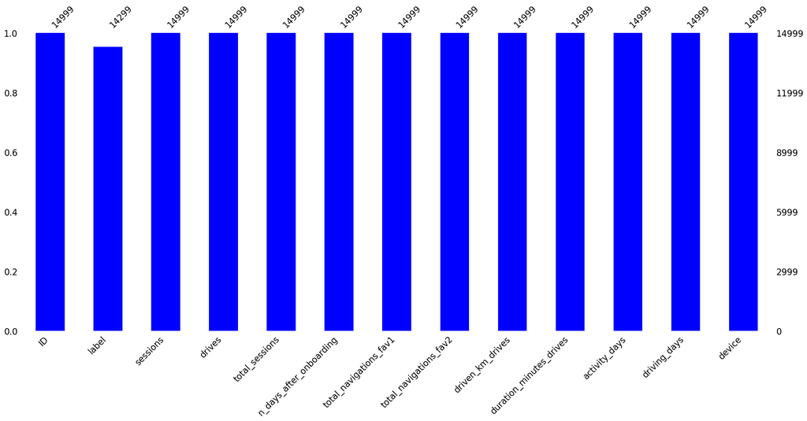

```python
import missingno as msno
msno.bar(data, color='blue')
```

```python
# Chech for data duplicates
data.duplicated().sum()
```

```
0
```

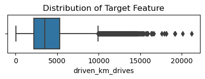

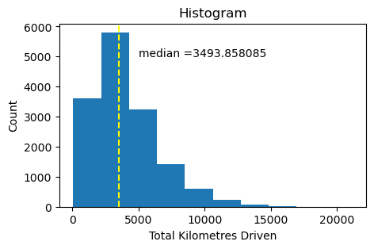

```python
plt.figure(figsize =(5,1))
g = sns.boxplot(data = data, x = 'driven_km_drives')
plt.title('Distribution of Target Feature')
plt.show()

plt.figure(figsize = (5,3))
plt.hist(data['driven_km_drives'])
plt.xlabel('Total Kilometres Driven')
plt.ylabel('Count')
plt.title('Histogram')


median = data['driven_km_drives'].median()
plt.axvline(median, color = 'yellow', linestyle = '--')
plt.text(5000, 5000, 'median =' +str(median), color = 'black')
plt.show()
```

```python
data['label'].unique()
```

```
array(['retained', 'churned', nan], dtype=object)
```

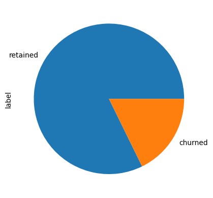

```python
data['label'].value_counts().plot(kind = 'pie')
```

```python
cat_feat = data.select_dtypes('object').columns.to_list()
cat_feat
```

```
['label', 'device']
```

```python
num_feat = data.select_dtypes(np.number).columns.to_list()
num_feat
```

```
['ID',
 'sessions',
 'drives',
 'total_sessions',
 'n_days_after_onboarding',
 'total_navigations_fav1',
 'total_navigations_fav2',
 'driven_km_drives',
 'duration_minutes_drives',
 'activity_days',
 'driving_days']
```

## Exploratory Data Analysis - Multivariate Analysis

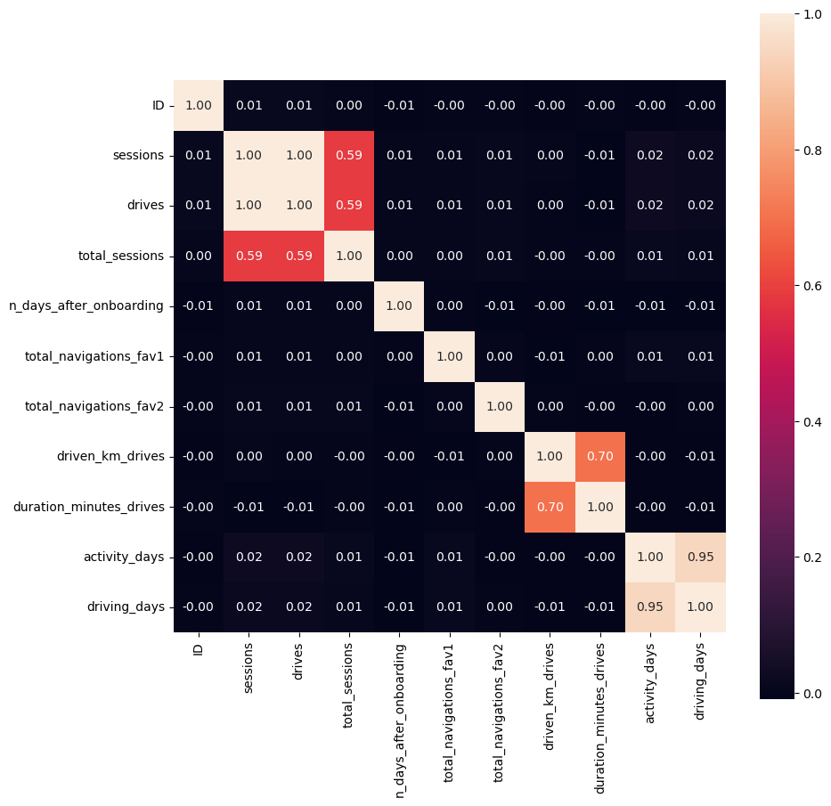

```python
# correlation between driven_km_drives and other variables in the dataset
plt.figure(figsize = (10, 10))
hm = sns.heatmap(data.corr(), cbar=True, annot = True, square=True, fmt ='.2f', annot_kws={'size':10})


import warnings
warnings.filterwarnings("ignore")
```

```python
data.corr()
```

|  | ID | sessions | drives | total_sessions | n_days_after_onboarding | total_navigations_fav1 | total_navigations_fav2 | driven_km_drives | duration_minutes_drives | activity_days | driving_days |
| --- | --- | --- | --- | --- | --- | --- | --- | --- | --- | --- | --- |
| ID | 1.000000 | 0.011240 | 0.010470 | 0.002909 | -0.005673 | -0.000606 | -0.000771 | -0.003561 | -0.001594 | -0.001887 | -0.001808 |
| sessions | 0.011240 | 1.000000 | 0.996822 | 0.589079 | 0.005676 | 0.005713 | 0.006185 | 0.002113 | -0.006113 | 0.024194 | 0.018973 |
| drives | 0.010470 | 0.996822 | 1.000000 | 0.586741 | 0.005216 | 0.005017 | 0.007572 | 0.001883 | -0.005855 | 0.024043 | 0.018847 |
| total_sessions | 0.002909 | 0.589079 | 0.586741 | 1.000000 | 0.004731 | 0.002137 | 0.006421 | -0.000416 | -0.001689 | 0.013449 | 0.009912 |
| n_days_after_onboarding | -0.005673 | 0.005676 | 0.005216 | 0.004731 | 1.000000 | 0.000435 | -0.008075 | -0.003213 | -0.009646 | -0.009725 | -0.008563 |
| total_navigations_fav1 | -0.000606 | 0.005713 | 0.005017 | 0.002137 | 0.000435 | 1.000000 | 0.002306 | -0.007690 | 0.002097 | 0.011066 | 0.010359 |
| total_navigations_fav2 | -0.000771 | 0.006185 | 0.007572 | 0.006421 | -0.008075 | 0.002306 | 1.000000 | 0.000081 | -0.004091 | -0.004036 | 0.001951 |
| driven_km_drives | -0.003561 | 0.002113 | 0.001883 | -0.000416 | -0.003213 | -0.007690 | 0.000081 | 1.000000 | 0.697866 | -0.002601 | -0.005487 |
| duration_minutes_drives | -0.001594 | -0.006113 | -0.005855 | -0.001689 | -0.009646 | 0.002097 | -0.004091 | 0.697866 | 1.000000 | -0.002830 | -0.005145 |
| activity_days | -0.001887 | 0.024194 | 0.024043 | 0.013449 | -0.009725 | 0.011066 | -0.004036 | -0.002601 | -0.002830 | 1.000000 | 0.947706 |
| driving_days | -0.001808 | 0.018973 | 0.018847 | 0.009912 | -0.008563 | 0.010359 | 0.001951 | -0.005487 | -0.005145 | 0.947706 | 1.000000 |

## Observations

- missing data in the label variable
- no duplicates
- presence of outliers outliers on the target feature
- The feature in the label is unbalanced as the difference between retained and churned are large

```python
# Drop missing features
data.dropna(inplace = True)
```

```python
data.isnull().sum()
```

```
ID                         0
label                      0
sessions                   0
drives                     0
total_sessions             0
n_days_after_onboarding    0
total_navigations_fav1     0
total_navigations_fav2     0
driven_km_drives           0
duration_minutes_drives    0
activity_days              0
driving_days               0
device                     0
dtype: int64
```

```python
# Dropping off redundant data
data.drop('ID', axis = 1, inplace = True)
```

```python
# Segment dataset
# y = data.pop('driven_km_drives')

y = data['driven_km_drives']
data.drop('driven_km_drives', axis =1, inplace = True)
```

```python
# Encoding of categorical features to numerical
data = pd.get_dummies(data)
```

```python
# Normalize dataset
from sklearn.preprocessing import RobustScaler, MinMaxScaler

# Instantiate scaler object
scaler = RobustScaler()
df_scaled = pd.DataFrame(scaler.fit_transform(data), columns = data.columns)
df_scaled.head()
```

|  | sessions | drives | total_sessions | n_days_after_onboarding | total_navigations_fav1 | total_navigations_fav2 | duration_minutes_drives | activity_days | driving_days | label_churned | label_retained | device_Android | device_iPhone |
| --- | --- | --- | --- | --- | --- | --- | --- | --- | --- | --- | --- | --- | --- |
| 0 | 2.579545 | 2.438356 | 0.846378 | 0.301315 | 0.815476 | -0.209302 | 0.311284 | 0.800000 | 0.500000 | 0.0 | 0.0 | 1.0 | -1.0 |
| 1 | 0.875000 | 0.808219 | 1.031244 | -0.299600 | -0.309524 | 1.279070 | 1.033399 | -0.200000 | -0.071429 | 0.0 | 0.0 | 0.0 | 0.0 |
| 2 | 0.659091 | 0.643836 | -0.142232 | 0.515723 | -0.422619 | -0.209302 | 0.080739 | -0.133333 | -0.285714 | 0.0 | 0.0 | 1.0 | -1.0 |
| 3 | -0.079545 | -0.109589 | -0.558792 | -0.991424 | 1.494048 | -0.046512 | -0.548455 | -0.600000 | -0.642857 | 0.0 | 0.0 | 0.0 | 0.0 |
| 4 | 0.318182 | 0.273973 | 0.058427 | -0.106918 | 0.565476 | -0.093023 | -0.159729 | 0.733333 | 0.428571 | 0.0 | 0.0 | 1.0 | -1.0 |

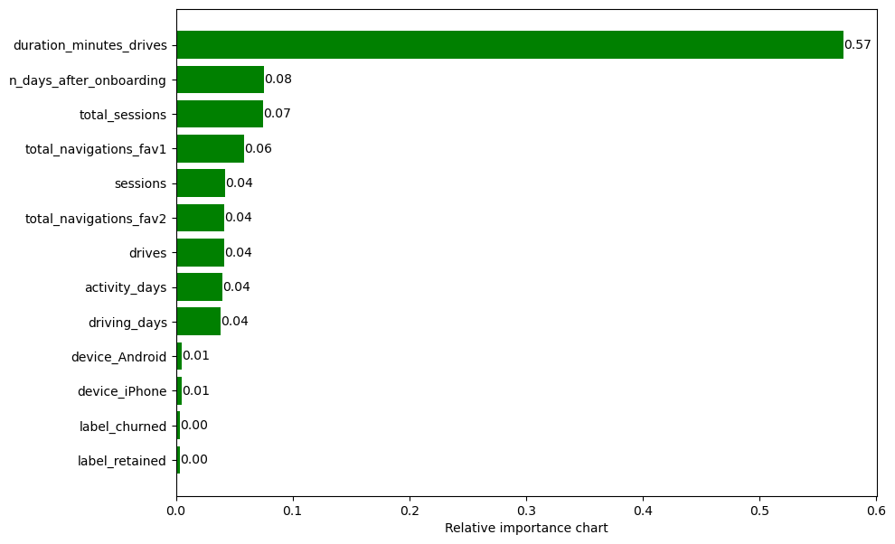

```python
from sklearn.ensemble import RandomForestRegressor
import matplotlib.pyplot as plt

# Instantiated the randomregressor model
feat_model = RandomForestRegressor()
feat_model.fit(df_scaled, y)

feature_names = list(df_scaled.columns)
importance = feat_model.feature_importances_
indices = np.argsort(importance)

plt.figure(figsize = (10,7))
plt.barh(range(len(indices)), importance[indices], color = 'green', align = 'center')
plt.yticks(range(len(indices)),[feature_names[i] for i in indices])
plt.xlabel('Relative importance chart')


# Add value labels to the bars
for i in range(len(indices)):
    plt.text(importance[indices][i], i, f'{importance[indices][i]:.2f}', ha='left', va='center')

plt.show()
```

```python
print(importance)
```

```
[0.04241583 0.04044002 0.07356234 0.07659541 0.0579964  0.04075888
 0.5745383  0.03989003 0.03710459 0.00338302 0.0031615  0.00496684
 0.00518686]
```

## Observations

The model tries to predict the Total kilometers driven during the month (driven_km_drives)

The above chart shows the predictive variables (in order of importance) with predictive power which determines Total kilometers driven during the month. From the chart, totoal duration driven in a month (duration_minutes_drives) appear to be more important with the highest predictive power followed by the number of days since a user signed up for the app (n_days_after_onboarding).

It's crystal clear that the variable, label_retained, is at the bottom lader of the predictors. However, other variables with least predictive power are devce_Android, device_iphone, and label_churned.

## Phase 2

- Splitting data into training and evaluation datasets
- Implimenting Manchine Learning/modelBuilding and Training
- creating a predictions file

```python
# Plit data into training and evalustion set
from sklearn.model_selection import train_test_split

x_train, x_test, y_train, y_test = train_test_split(df_scaled, y, test_size = 0.3, random_state = 1)

# x_train will contain the training feature data.
# x_test will contain the evaluation (test) feature data.
# y_train will contain the training target data.
# y_test will contain the evaluation (test) target data.
```

```python
x_train.shape,x_test.shape
```

```
((10009, 13), (4290, 13))
```

```python
from sklearn.linear_model import LinearRegression
from sklearn.tree import DecisionTreeRegressor
from sklearn.ensemble import GradientBoostingRegressor
```

```python
# intantiating model
lin_reg = LinearRegression()
dec_tree = DecisionTreeRegressor()
gbost_mod= GradientBoostingRegressor() # Gradient boosting is an ensemble learning technique that combines multiple weak models (typically decision trees) to create a stronger predictive model.
```

```python
# model  fitting and training

lin_reg.fit(x_train, y_train)
dec_tree.fit(x_train, y_train)
gbost_mod.fit(x_train, y_train)
```

```
GradientBoostingRegressor()
```

```python
# Creating prediction files for our models
lin_pred = lin_reg.predict(x_test)
dec_pred = dec_tree.predict(x_test)
g_pred = gbost_mod.predict(x_test)
```

## Phase 3

  > confusion matrix, MSE(Mean Squared Errpr), MAE(Mean Absolute Error), RSME, r2_score, classification report

```python
from sklearn.metrics import mean_squared_error, r2_score
```

## Brief note on the metrics

- R-squared (R²) Score: R-squared is a statistical measure of the proportion of the variance in the dependent variable (target) that can be explained by the independent variables (features) in a regression model.
- MSE is a measure of the average squared difference between the actual and predicted values. It quantifies the overall model prediction error.
- Root Mean Squared Error (RMSE) Score:RMSE is the square root of the MSE and is expressed in the same units as the target variable. It provides an estimate of the standard deviation of prediction errors.
- Adjusted R-squared Score: Adjusted R-squared is a modified version of the R-squared score that accounts for the number of predictors in the model. Adjusted R-squared takes into account the number of predictors in your model. It helps to account for the potential problem of overfitting when you add more variables to a regression model.

```python
# linear regression model
# evaluate models using the validation dataset
mse = mean_squared_error(y_test, lin_pred)
rmse = np.sqrt(mse)
r2 = r2_score(y_test, lin_pred)

# To calculate the adjusted R-squared follow the steps
# Number of observations
n = len(y_test)

# Number of predictors in the model
num_predictors = x_train.shape[1]  # Replace with the actual number of predictors

# Calculate the adjusted R-squared
adjusted_r2 = 1 - (1 - r2) * (n - 1) / (n - num_predictors - 1)


print(f'For the linear regression model r2 score: {r2}')
print(f'For the linear regression model mse score: {mse}')
print(f'For the linear regression model rmse score: {rmse}')
print(f'For the linear regression model Adjusted R-squared: {adjusted_r2}')
```

```
For the linear regression model r2 score: 0.46673180207800025
For the linear regression model mse score: 3383409.92383405
For the linear regression model rmse score: 1839.404774331645
For the linear regression model Adjusted R-squared: 0.4651105470328679
```

## Interpretations

- R-squared (R²) Score: The R² score is approximately 0.4667. This means that about 46.67% of the variance in the target variable is explained by the linear regression model. It indicates the goodness of fit, with a higher R² value suggesting a better fit.
- Mean Squared Error (MSE) Score: The MSE score is approximately 3,383,409.92. A higher MSE indicates larger errors between predictions and actual values, and a lower MSE implies better predictive accuracy.
- Root Mean Squared Error (RMSE) Score: The RMSE score is approximately 1,839.40. Smaller RMSE values indicate better model accuracy, as it represents the average magnitude of prediction errors.
- Adjusted R-squared Score: The adjusted R-squared is approximately 0.4651. This adjusted value is slightly lower than the regular R-squared and is often used to penalize the inclusion of irrelevant predictors. It suggests that approximately 46.51% of the variance in the target variable is explained while considering the model's complexity (number of predictors).

Overall, the linear regression model appears to explain a moderate proportion of the variance in the target variable, as indicated by the R-squared score. The model's predictive accuracy, as measured by MSE and RMSE, suggests that there is some prediction error, but the RMSE is reasonable given the context of the problem. The adjusted R-squared accounts for the model's complexity and suggests that the model is reasonably effective in explaining the variance, considering the number of predictors used.

```python
# the decision tree model
# evaluate models using the validation dataset
mse = mean_squared_error(y_test, dec_pred)
rmse = np.sqrt(mse)
r2 = r2_score(y_test, dec_pred)

# To calculate the adjusted R-squared follow the steps
# Number of observations
n = len(y_test)

# Number of predictors in the model
num_predictors = x_train.shape[1]  # Replace with the actual number of predictors

# Calculate the adjusted R-squared
adjusted_r2 = 1 - (1 - r2) * (n - 1) / (n - num_predictors - 1)


print(f'For the decision tree model r2 score: {r2}')
print(f'For the decision tree model mse score: {mse}')
print(f'For the decision tree model rmse score: {rmse}')
print(f'For the linear regression model Adjusted R-squared: {adjusted_r2}')
```

```
For the decision tree model r2 score: -0.15097767286300345
For the decision tree model mse score: 7302571.755921042
For the decision tree model rmse score: 2702.3271000974405
For the linear regression model Adjusted R-squared: -0.15447690339322317
```

```python
# the boosting model
# evaluate models using the validation dataset
mse = mean_squared_error(y_test, g_pred)
rmse = np.sqrt(mse)
r2 = r2_score(y_test, g_pred)

# To calculate the adjusted R-squared follow the steps
# Number of observations
n = len(y_test)

# Number of predictors in the model
num_predictors = x_train.shape[1]  # Replace with the actual number of predictors

# Calculate the adjusted R-squared
adjusted_r2 = 1 - (1 - r2) * (n - 1) / (n - num_predictors - 1)


print(f'For the boosting model r2 score: {r2}')
print(f'For the boosting model mse score: {mse}')
print(f'For the boosting model rmse score: {rmse}')
print(f'For the boosting model Adjusted R-squared: {adjusted_r2}')
```

```
For the boosting model r2 score: 0.45845576640371255
For the boosting model mse score: 3435918.626470927
For the boosting model rmse score: 1853.6231079890342
For the boosting model Adjusted R-squared: 0.4568093503520868
```

## Interpretation and comparison of the 3 models

In light of this, Linear Regression model is the most performing model, followed by Boosting model, while Decision Tree model performs the poorest.